# Introduction SQL in RStudio, part 2, teacher version

Antoinette Littel

June 2019

In part 2 were are focussing on the aggregate functions (COUNT, MAX, MIN, AVG, SUM) in combination with the GROUP BY.

## Connecting to the database

The first chunk in this Notebook will run automatically when you make the SQL statements. It loads the libraries you need and connects to the database ‘CapeCodd.db’ that should be in your folder.

## Database design

Below is the design of the database. You should have this picture in the images folder of your workdirectory. You can open the picture next to your Notebook, so that you can see the design while creating your queries.

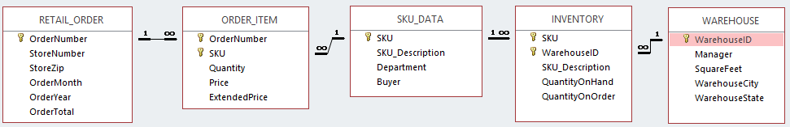

## Assignments

Make a SQL query for the following questions.

A. What is the total price per order (use ORDER_ITEM)?

| OrderNumber | SUM(Price) |
| --- | --- |
| 1000 | 430 |
| 2000 | 100 |
| 3000 | 400 |

B. What is the total price per order, for orders that have total quantity of items more than 2?

| OrderNumber | SUM(Price) | Quantity |
| --- | --- | --- |
| 2000 | 50 | 4 |

C. What is the total price per order, for orders with more than 2 different items?

| OrderNumber | SUM(Price) |
| --- | --- |
| 1000 | 430 |
| 2000 | 100 |
| 3000 | 400 |

E. For which SKU’s the **average** QuantityOnHand is greater than the **highest** QuantityOnOrder for any Warehouse?

| SKU | AVG(QuantityOnHand) | MAX(QuantityOnOrder) |
| --- | --- | --- |
| 100100 | 162.50 | 50 |
| 100200 | 156.25 | 100 |

Having = WHere ama za Group By KURVO

F. For which Warehouses the total QuantityOnHand is greater than the total QuantityOnOrder?

| WarehouseID | SUM(QuantityOnHand) | SUM(QuantityOnOrder) |
| --- | --- | --- |
| 100 | 1862 | 1630 |
| 300 | 1825 | 1050 |

G. For which Warehouses the total QuantityOnHand for Tents is greater than half the total QuantityOnOrder?

| WarehouseID | SUM(QuantityOnHand) | SUM(QuantityOnOrder) / 2 | SKU_Description |
| --- | --- | --- | --- |
| 300 | 350 | 0 | Half-dome Tent |

8. Give the total quantity of all sku items in all the warehouses. Name the columns as sku, sku_description and QOH?

| sku | sku_description | QOH |
| --- | --- | --- |
| 1408600 | Std. Scuba Tank, Yellow | 250 |
| 1408600 | Std. Scuba Tank, Yellow | 100 |
| 1408600 | Std. Scuba Tank, Yellow | 100 |
| 1408600 | Std. Scuba Tank, Yellow | 200 |

## Extra practice

### GROUP BY, multiple columns

E1. How many items(SKU’s) where ordered per price?

E2. How many different items(different SKU codes) are in the inventory per warehouse?

E3. How many different items(different SKU codes) are in the inventory for Warehouse 300?

E4. How many different items(different SKU codes) are in the inventory for Warehouse 300? But now, count only the items where the QuantityOnHand is higher than 50.

E5. How many items are there in total (use QuantityOnHand) in the inventory per warehouse?

## Challenging assignments

C1. Visualize the QuantityOnHand per SKU. Make two chunks: a sql chunk and a R chunk for `ggplot`

Remember to use the `{r}` tag in your chunk to switch to regular R again.